# hospital_administration

```python
import pandas as pd
import numpy as np
import matplotlib.pyplot as plt
import seaborn as sns
sns.set()
```

```python
df = pd.read_csv('train.csv')
```

```python
df.head()
```

|  | index | encounter_id | patient_id | race | gender | age | weight | time_in_hospital | medical_specialty | num_lab_procedures | ... | X19 | X20 | X21 | X22 | X23 | X24 | X25 | change | diabetesMed | readmitted |
| --- | --- | --- | --- | --- | --- | --- | --- | --- | --- | --- | --- | --- | --- | --- | --- | --- | --- | --- | --- | --- | --- |
| 0 | 69375 | 197029140 | 51521940 | Hispanic | Male | [80-90) | ? | 4 | Emergency/Trauma | 39 | ... | No | No | No | No | No | No | No | No | Yes | 1 |
| 1 | 57272 | 163571946 | 92631357 | Caucasian | Male | [60-70) | ? | 3 | Emergency/Trauma | 34 | ... | No | No | No | No | No | No | No | No | No | 0 |
| 2 | 82347 | 256497366 | 30023982 | Caucasian | Female | [50-60) | ? | 6 | Nephrology | 50 | ... | No | Down | No | No | No | No | No | Ch | Yes | 1 |
| 3 | 89608 | 289891212 | 93606021 | AfricanAmerican | Female | [70-80) | ? | 5 | ? | 63 | ... | No | Down | No | No | No | No | No | Ch | Yes | 1 |
| 4 | 24091 | 81873900 | 23464296 | Caucasian | Male | [70-80) | ? | 9 | Psychiatry | 17 | ... | No | No | No | No | No | No | No | No | No | 1 |

5 rows × 49 columns

```python
df.shape
```

```
(66587, 49)
```

```python
df['readmitted'].value_counts()/df.shape[0]
```

```
0    0.537988
1    0.462012
Name: readmitted, dtype: float64
```

Dataset doesn't have any description, but one can infer that its a dataset from hospital administration. The target is binary - whether the patient was readmitted or not. It's almost balanced, so accuracy score should be a good enough metric, unless otherwise mentioned.

```python
todrop=['index','encounter_id','patient_id','weight','medical_specialty',
        'diag_1','diag_2','diag_3','diag_4',
        'X6','X8','X11','X15','X16','X17',
        'X18','X19','X22','X23','X24','X25']
df = df.drop(todrop,axis=1)
```

##### Dropping Columns

Dropping above columns above because some have one one value, some have an overwhelming majority of one value, with others numbering less than 70 - when total is 66587, that's ~0.1%. I haven't included the value_counts() of the columns in this notebook to increase readability.  
'diag_1', 'diag_2','diag_3','diag_4','X6','X8','X11','X15','X16','X17','X18','X19','X22','X23','X24','X25' - drop these. They are mostly float but a bunch of entries start with letters and there are no explanations.

##### Encoders For Categorical Columns

'race' - Turn this into caucasian vs. non-caucasian. Sounds racist, but there is a disparity in the quality of health-care received by white people and minorities. Also replace the unknown '?' in this column with the majority class, which is (no surprises) caucasian.  
'age' - Turn this into a linear scale.  
'change', 'diabetesMed' - Simple binary encoder.  
'X1','X2','X3','X4','X5','X7','X9','X10','X12','X13','X14','X20','X21' - custom encoders for them. See below.

```python
df['race']=df['race'].replace('?','Caucasian') #replacing with majority class
df = df.drop(df['gender'].loc[df['gender'] == 'Unknown/Invalid'].index,axis=0)

#we'll call the encoder function after plotting
def cat_encoders(df):
    #gender encoding - binary
    enc_gender = {'Female':1,'Male':0}
    df['gender'] = df['gender'].replace(enc_gender)

    #age encoded to a linear scale
    enc_age = {'[0-10)':0,'[10-20)':1,'[20-30)':2,'[30-40)':3,'[40-50)':4,
           '[50-60)':5,'[60-70)':6,'[70-80)':7,'[80-90)':8,'[90-100)':9}
    df['age'] = df['age'].replace(enc_age)

    #X encoders
    enc_X1 = {'None':0,'Norm':1,'>200':2,'>300':3}
    df['X1'] = df['X1'].replace(enc_X1)

    enc_X2 = {'None':0,'Norm':2,'>7':2,'>8':3}
    df['X2'] = df['X2'].replace(enc_X2)

    enc_Xn = {'No':0,'Steady':1,'Down':2,'Up':3} #to encode X3, X4, X5, X7, X9, X10, X12, X13, X14, X20, X21
    Xn_cols = ['X3','X4','X5','X7','X9','X10','X12','X13','X14','X20','X21']
    df[Xn_cols] = df[Xn_cols].replace(enc_Xn)

    #encoding change
    enc_ch = {'Ch':1,'No':0}
    df['change'] = df['change'].replace(enc_ch)

    #encoding diabetesMed
    enc_diab = {'Yes':1,'No':0}
    df['diabetesMed'] = df['diabetesMed'].replace(enc_diab)

    idx_cau = df['race'].loc[df['race']=='Caucasian'].index
    idx_ncau = df['race'].loc[df['race']!='Caucasian'].index

    df['race'].loc[idx_cau] = 1
    df['race'].loc[idx_ncau] = 0

    return df
```

```python
num_cols = df.select_dtypes(include=np.number).columns.tolist()
cat_cols = df.select_dtypes(include='O').columns.tolist()
num_cols.remove('readmitted')
```

# Visualizing the Data

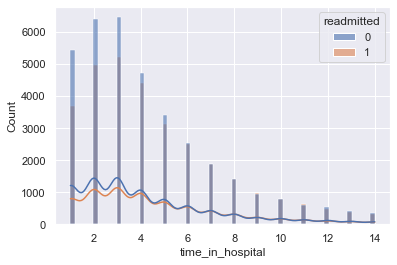

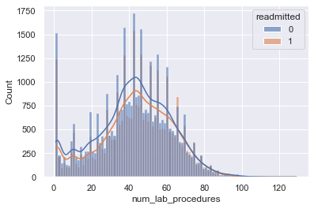

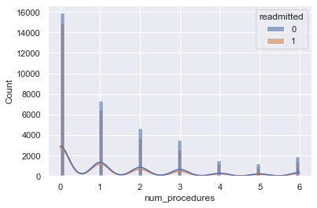

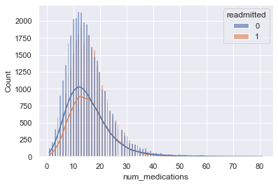

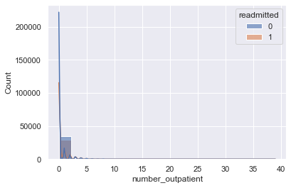

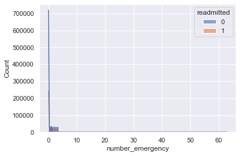

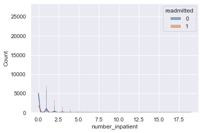

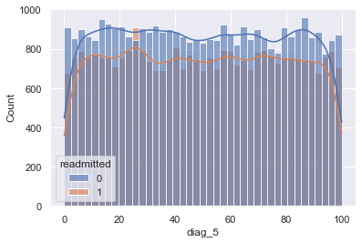

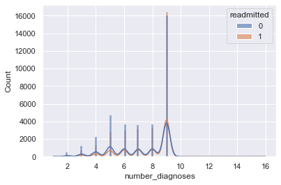

```python
for i in num_cols:
    sns.histplot(data=df,x=i,hue='readmitted',kde=True,alpha=0.6)
    plt.xlabel(i)
    plt.show()
```

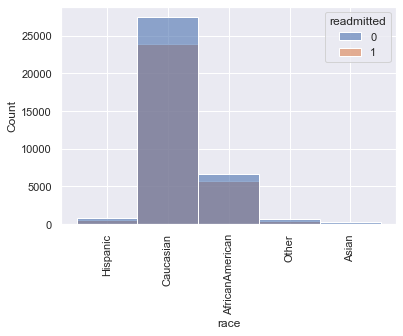

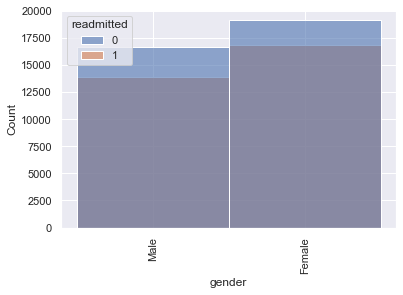

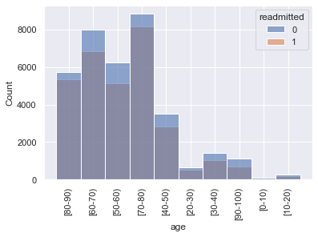

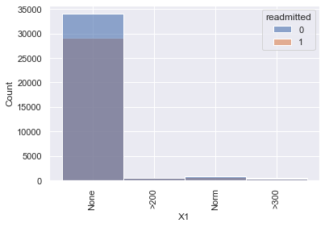

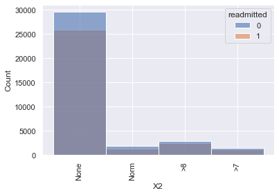

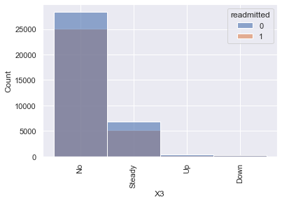

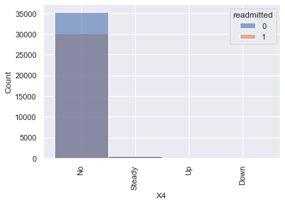

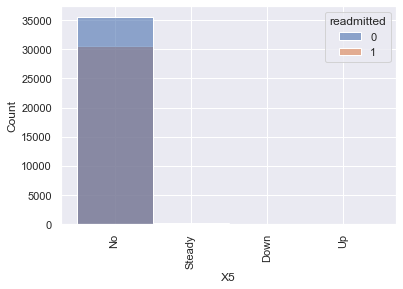

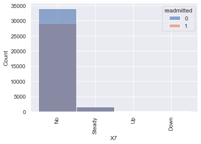

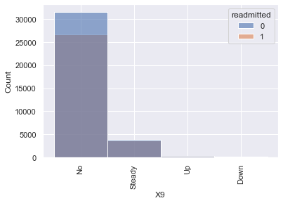

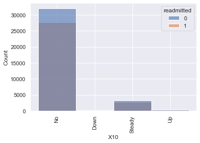

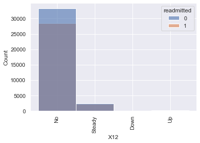

[6 more figures not shown]

```python
for i in cat_cols:
    sns.histplot(data=df,x=i,hue='readmitted',alpha=0.6)
    plt.xlabel(i)
    plt.xticks(rotation=90)
    plt.show()
```

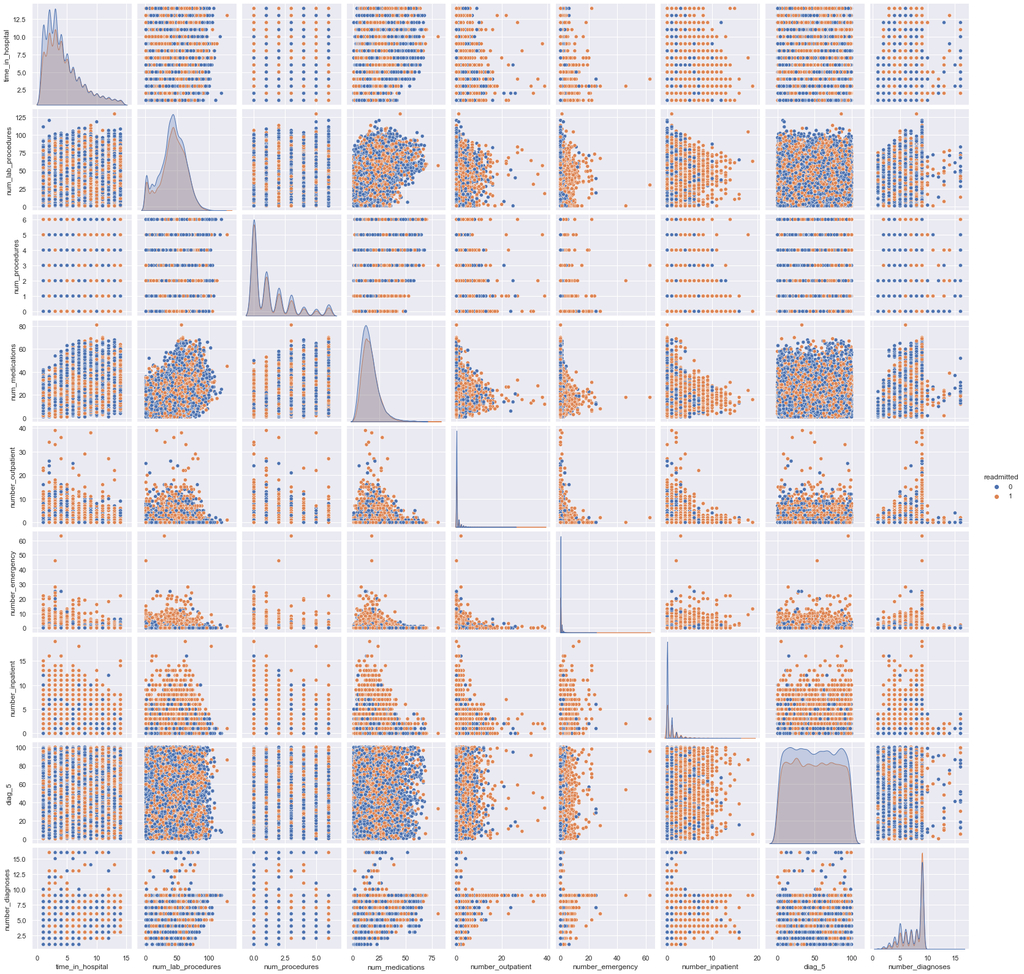

```python
sns.pairplot(df,hue='readmitted')
plt.show()
```

```python
df = cat_encoders(df)
```

# Model Fitting

```python
from sklearn.preprocessing import MinMaxScaler
from sklearn.model_selection import train_test_split
```

```python
trainX, testX, trainY, testY = train_test_split(df.drop('readmitted',axis=1),df['readmitted'],test_size=0.2,random_state=2)
```

```python
scaler = MinMaxScaler()
scaler.fit(trainX)

def data_transform(X,y):
    return scaler.transform(X),y

X_train, y_train = data_transform(trainX, trainY)
X_test, y_test = data_transform(testX, testY)
```

```python
from sklearn.linear_model import LogisticRegression, SGDClassifier
from sklearn.naive_bayes import GaussianNB
from sklearn.svm import SVC
from sklearn.tree import DecisionTreeClassifier
from catboost import CatBoostClassifier
from xgboost import XGBClassifier
from lightgbm import LGBMClassifier

from sklearn.metrics import accuracy_score
```

```python
classifiers = [SGDClassifier(),
               GaussianNB(), DecisionTreeClassifier(),
               LGBMClassifier(), CatBoostClassifier(verbose=False),XGBClassifier()]

scores = pd.DataFrame(columns=['Classifier','TestScore','TrainScore'])

for i in classifiers:
    i.fit(X_train, y_train)
    y_pred_test = i.predict(X_test)
    y_pred_train = i.predict(X_train)
    test_score = accuracy_score(y_test, y_pred_test)
    train_score = accuracy_score(y_train, y_pred_train)
    scores.loc[len(scores.index)] = [i.__class__.__name__,test_score,train_score]
```

[output not shown]

```python
scores.sort_values(by='TestScore')
```

|  | Classifier | TestScore | TrainScore |
| --- | --- | --- | --- |
| 1 | GaussianNB | 0.582639 | 0.589754 |
| 0 | SGDClassifier | 0.601937 | 0.606293 |
| 3 | LGBMClassifier | 0.639558 | 0.672937 |
| 4 | CatBoostClassifier | 0.650372 | 0.706034 |
| 5 | XGBClassifier | 0.659383 | 0.727604 |
| 2 | DecisionTreeClassifier | 0.728467 | 1.000000 |

Performance is pretty luke-warm. At least there is not a lot of over-fitting going on - except for you DecisionTree